# statComp_hw3

凌浩东

10/21/2021

## 1. Exercises 5.12, and 5.14.

### 5.12

Suppose $l \leq \frac{g(x)}{f(x)} \leq u$, then

$$\begin{align*}
Var(\hat{\theta}_{IS}) &= Var\left(\frac{1}{m}\sum_{i=1}^{m}\frac{g(x_i)}{f(x_i)}\right)\\
&= \frac{1}{m^2}\sum_{i=1}^{m}Var\left(\frac{g(x_i)}{f(x_i)}\right)\\
&= \frac{1}{m^2}\sum_{i=1}^{m}\left(\int\frac{g^2(x_i)}{f(x_i)}dx_i - \theta^2\right)
\end{align*}$$

where

$$l\theta = l\int g(x_i)dx_i \leq \int\frac{g^2(x_i)}{f(x_i)}dx_i \leq u\int g(x_i)dx_i = u\theta$$

thus

$$\frac{1}{m}(l\theta - \theta^2) \leq Var(\hat{\theta}_{IS}) \leq \frac{1}{m}(u\theta - \theta^2)$$
i.e., $Var(\hat{\theta}_{IS})$ is bounded.

### 5.14

First, let’s take a look at our target function
$$\begin{align*}
&g(x) = \frac{x^2}{\sqrt{2\pi}}e^{-\frac{x^2}{2}} & x>1
\end{align*}$$

```r
g <- function(x) {
  x^2 * exp(-x^2 / 2) / sqrt(2*pi) * (x > 1)
}

x <- seq(1, 10, length = 10000)
y <- g(x)
df <- data.frame(x, y)
c(x[ggpmisc:::find_peaks(df$y)], y[ggpmisc:::find_peaks(df$y)])
```

```
## [1] 1.4140414 0.2935253
```

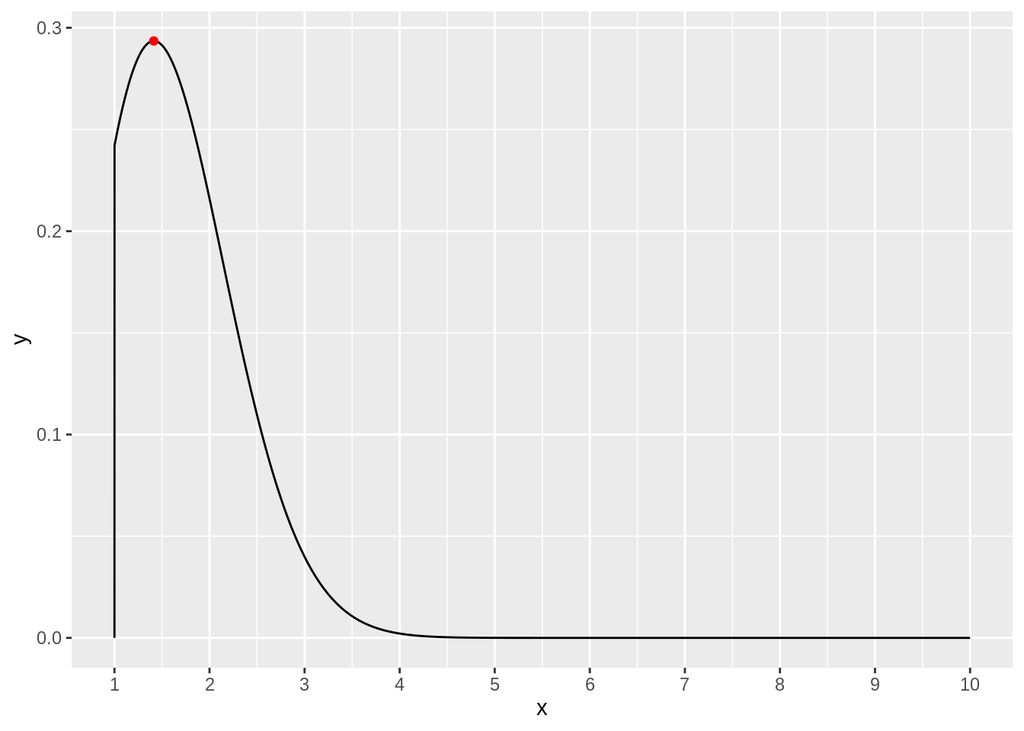

```r
ggplot(df, aes(x = x, y = y)) + geom_line() + stat_peaks(col = 'red') +
  scale_x_continuous(breaks=seq(0, 10, 1))
```

We can see that after a sharp ascend until 1.4 and descend to nearly 0 at around 4. Hence we use two target function, one is a shifted norm density function, the other is a cauchy density function.

```r
set.seed(42)
m <- 10000

theta.hat <- se <- numeric(2)

x <- rnorm(m, mean = 1.4)
fg <- g(x) / (dnorm(x, mean = 1.4))
theta.hat[1] <- mean(fg)
se[1] <- sd(fg)

x <- rcauchy(m, location = 1.4, scale = 1)
fg <- g(x) / dcauchy(x, location = 1.4, scale = 1)
theta.hat[2] <- mean(fg)
se[2] <- sd(fg)

theta.hat
```

```
## [1] 0.4005384 0.3988719
```

```r
se
```

```
## [1] 0.3134021 0.4297568
```

## 2

> Given two random variables X and Y , prove the law of total variance

$$var(Y) = E\{var(Y|X)\} + var\{E(Y|X)\}$$

> Be explicit at every step of your proof.

$$\begin{align*}
E\{var(Y|X)\} &= E\{E(Y^2|X) - [E(Y|X)]^2\}
= E(Y^2) - E\{[E(Y|X)]^2\} \\
var\{E(Y|X)\} &= E\{[E(Y|X)]^2\} - \{E[E(Y|X)]\}^2 = E\{[E(Y|X)]^2\} - [E(Y)]^2\\
\end{align*}$$
Hence,
$$E\{var(Y|X)\} + var\{E(Y|X)\} = E(Y^2) - [E(Y)]^2 = var(Y)$$

## 3

> Define $\theta = \int_Ag(x)dx$, where A is a bounded set and $g \in \mathcal{L}_2(A)$. Let f be an importance function which is a density function supported on the set A.
> 1. Describe the steps to obtain the importance sampling estimator $\hat{\theta}_n$, where n is the number of random samples generated during the process.
- generate n random variables from f.
- caculate the mean of $\frac{g(x)}{f(x)}$, assign it to $\hat{\theta}_n$.
> 2. Show that the Monte Carlo variance of $\hat{\theta}_n$ is $var(\hat{\theta}_n) = \frac{1}{n}\left\{\int_A\frac{g^2(x)}{f(x)}dx-\theta^2\right\}$.

$$\begin{align*}
var(\hat{\theta}_n) &= var\left(\frac{1}{n}\sum_{i=1}^{n}\frac{g(x_i)}{f(x_i)}\right) \\
&= \frac{1}{n^2} \sum_{i = 1}^{n} var\left(\frac{g(x_i)}{f(x_i)}\right) \\
&= \frac{1}{n^2} \sum_{i = 1}^{n}\left(E\left[\left(\frac{g(x_i)}{f(x_i)}\right)^2\right] - \left(E\left[\frac{g(x_i)}{f(x_i)}\right]\right)^2\right) \\
& = \frac{1}{n^2} \sum_{i = 1}^{n} \left(\int_A\frac{g^2(x_i)}{f^2(x_i)}f(x_i)dx_i - \int_A\frac{g(x_i)}{f(x_i)}f(x_i)dx_i\right)\\
& = \frac{1}{n} \left\{\int_A\frac{g^2(x)}{f(x)}dx-\theta^2\right\}
\end{align*}$$

> 3. Show that the optimal importance function $f^*$ , i.e., the minimizer of $var(\hat{\theta}_n)$, is $f*(x) = \frac{|g(x)|}{\int_A|g(x)|dx}$, and derive the theoretical lower bound of $var(\hat{\theta}_n)$.

From Cauchy-Schwartz inequality, we know that
$$\int_A\frac{g^2(x)}{f(x)}dx = \int_A\frac{g^2(x)}{f(x)}dx\cdot 1
= \int_A\frac{g^2(x)}{f(x)}dx \int_Af(x)dx \geq \left(\int_Ag(x)dx\right)^2$$
where the equality holds when $f(x) \propto |g(x)|$.

Hence the minimizer is $f*(x) = \frac{|g(x)|}{\int_A|g(x)|dx}$.

The theoretical lower bound is $\frac{1}{n} \left\{\left(\int_Ag(x)dx\right)^2-\theta^2\right\} = 0$.